# A few notes about decomposing the two way fixed effects estimator

By Hans H. Sievertsen (h.h.sievertsen@bristol.ac.uk)

This version: 05/06/2020; [link to most recent version](https://github.com/hhsievertsen/twowayfedecomp/raw/master/slides/Notes_on_DiD_weights.pdf)

# What is this?

**Objective**

- Introduce the Chaisemartin & D’Haultfoeuille (forthcoming, AER; CD) & Goodman-Bacon (2019 WP; GB) decomposition of the two way fixed effects estimator and link them.

**Disclaimer**

- The slides represent my understanding. It might be wrong and there will be mistakesg. Please let me know.
- There is **a lot** more in CD’s and GB’s papers.
- I don’t discuss assumptions (!) and extensions.
- Please see the original papers.

# The traditional difference-in-differences (DD)

The running example

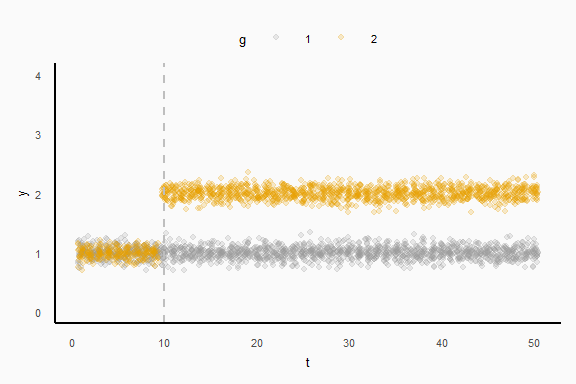

- $t$: period, $g$: group, $y$: outcome, $d$: treatment indicator, $g=1$ is never treated, $g=2$ is treated from $t=10$.

## The traditional DD

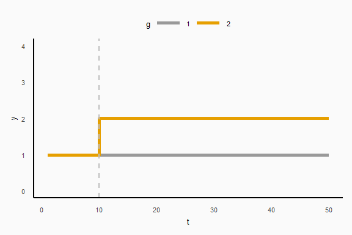

- $t$: period, $g$: group, $y$: outcome, $d$: treatment indicator, $g=1$ is never treated, $g=2$ is treated from $t=10$.
- DD estimate:
  $$\begin{equation}\hat{\beta}^{DD}=(\bar{Y}_{g=2,t\geq
  10}-\bar{Y}_{g=2,t<10})-(\bar{Y}_{g=1,t\geq
  10}-\bar{Y}_{g=1,t<10})
  \end{equation}$$
- As seen in for example *Card & Krueger (1994) “Minimum Wages and Employment: A Case Study of the Fast Food Industry in New Jersey and Pennsylvania”, AER, 84, 772-784.*

## DD with more groups

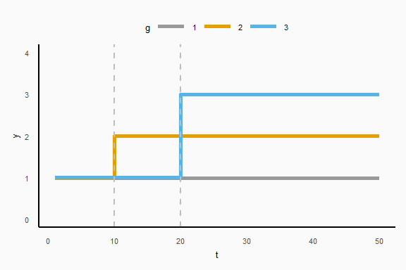

- Add another group, $g=3$ that gets treated from period $t=20$.
- DD estimate is then often estimated as $\hat{\beta}_{fe}$ from an OLS regression of:
  $$\begin{equation}y_{i,g,t}=\alpha+\gamma'
  G_{g}+\psi' T_{t}+ \beta_{fe}
  D_{g,t}+e_{i,g,t}\end{equation}$$
- $\beta_{fe}$ is also called the two-way FE estimator (we have both group and period fixed effects).

## What $\beta_{fe}$ capturing and how does it relate to $\hat{\beta}^{DD}$ ?

**Bit question: What is ${\beta}_{fe}$ capturing?**

- *Chaisemartin & D’Haultfoeuille (CD): “Two-way fixed effects estimators with heterogeneous treatment effects” (forthcoming, AER)*
  - **Decomposition of $\hat{\beta}_{fe}$ in weighted ATEs across $(t,g)$ cells.**
  - Applicable to 2-way (e.g., group & time) fixed effects approaches.
- *Goodman-Bacon (GB): “Difference-in-Differences with Variation in Treatment Timing” (2019, WP)*
  - **Decomposition of $\hat{\beta}_{fe}$ in weighted $\hat{\beta}^{DD}$s**
  - Applicable to staggered adoptation designs.
- (There are other papers.)

**Let’s start with the GB approach**

## The GB decomposition

- We consider the example with 3 groups and a staggered introduction of a policy:

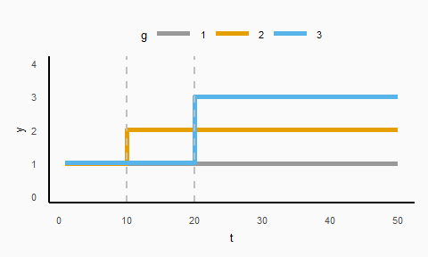

- Goodman-Bacon: we can decompose this in 4 separate $\hat{\beta}^{DD}$:

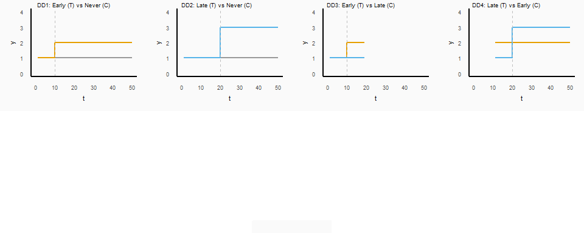

## GB: ${\beta}^{DD}$ is a weighted average of the separate DDs

- In our running example, ${\beta}^{DD}$ is the weighted average across these 4 DDs:

$$\begin{equation}
\hat{\beta}_{fe}=w_1\hat{\beta}^{DD}_1+w_2\hat{\beta}^{DD}_2+w_3\hat{\beta}^{DD}_3+w_4\hat{\beta}^{DD}_4
\end{equation}$$

- Key insight: $w\neq$ population shares, but also depends on when a group gets treated.
- See Theorem 1 in GB for the general expression of (3) (equation 10a in his paper) and the definition of the weights.
- GB then shows that:

$$\begin{align}
\beta^{DD}=VWATT+VWCT-\Lambda ATT
\end{align}$$

where:

- $VWATT$: variance weighted ATE.
- $VWCT$: variance weighted common trends.
- $\Delta ATT$ time varying treatment effect.

(see page 12 in Goodman-Bacon, 2019)

## Is it a problem? Let’s consider an example.

**DGP**

- treatment effects: group2=1 (yellow), group3=2 (blue)
- equal group sizes
- **population weighted average treatment effects=1.5**

**Estimated effects**

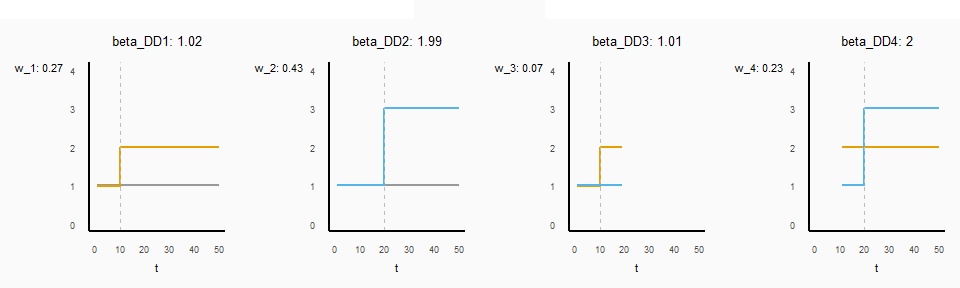

- $\hat{\beta}_{fe}=$ 0.27 $\times$ 1.02+ 0.43 $\times$ 1.99+ 0.07 $\times$ 1.01+ 0.23 $\times$ 2=1.66
- Group 3 (blue) gets a higher weight because it is treated more in the middle.
- Not a problem if you know that it is not population weighted.

## What about the last term ($\Lambda ATT$)? Treatments effects varying over time.

**DGP**

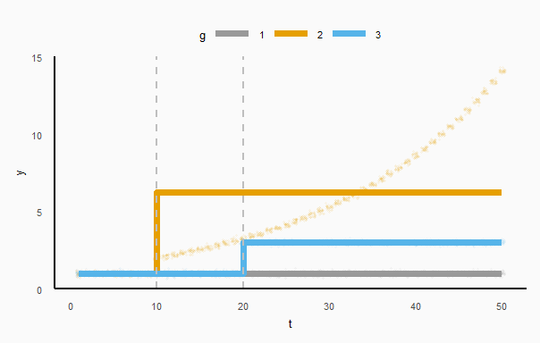

- **BUT** $\hat{\beta}_{fe}=1.73$
- That issmaller than the average treatment effect in any of the groups!
- Why?

## What about the last term ($\Lambda ATT$)? Treatments effects varying over time.

**DGP**

**Decomposing the estimated effect using GBs approach**

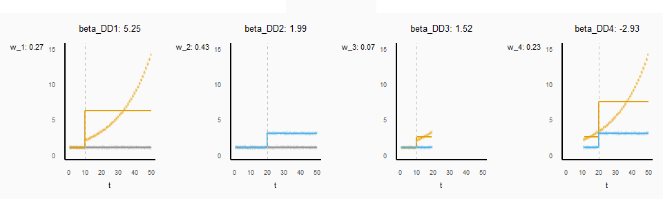

- $\hat{\beta}_{fe}=$ 0.27 $\times$ 5.25+ 0.43 $\times$ 1.99+ 0.07 $\times$ 1.52+ 0.23 $\times$ -2.93=1.73

What if we left out the last DD?

- $\hat{\beta}_{fe}=$ 0.27 $\times$ 5.25+ 0.43 $\times$ 1.99+ 0.07 $\times$ 1.52= 2.39

## GB Summary

*Goodman-Bacon (GB): “Difference-in-Differences with Variation in Treatment Timing” (2019, WP)*

**Take aways**

- $\hat{\beta}_{fe}=$ is a weighted average of all the DDs possible combinations
- Weights $\neq$ popualion shares, but depend on treatment timing. Groups that are treated towards the middle of the period receive more weight.
- If treatment effects vary over time, some DDs can be negative.
- Also relevant for the common trend assumption: Violations can offset each other.
- GB derives test for violation of weighted common trend assumption.

**What we should do**

- Compute weights and DDs and check whether any of them are negative. (“bacondecomp” function in R and Stata).
- Test for violation of common trend assumption.
- Read the paper (there is much more than ocvered here)

## Now to the CD decomposition

*Chaisemartin & D’Haultfoeuille (CD): “Two-way fixed effects estimators with heterogeneous treatment effects” (forthcoming, AER)*

**Decompose $\beta_{fe}$ in weighted TEs across $(g,t):D_{g,t}=1$ cells**

- (back to the original example with constant treatment effects over time)

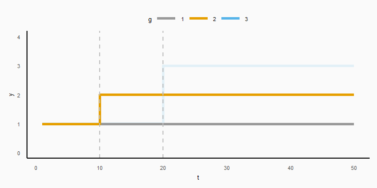

## The CD decomposition

*Chaisemartin & D’Haultfoeuille (CD): “Two-way fixed effects estimators with heterogeneous treatment effects” (forthcoming, AER)*

**Decompose $\beta_{fe}$ in weighted TEs across $(g,t):D_{g,t}=1$ cells**

- i.e. for the cell $g=2,t=10$, weight number: 1

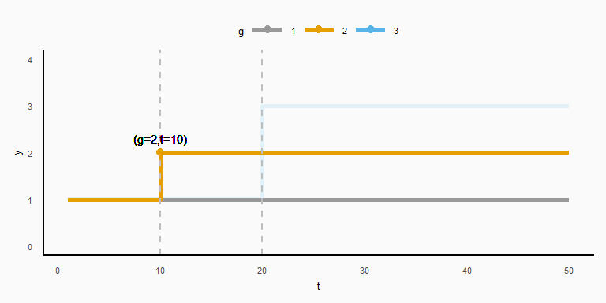

## The CD decomposition

*Chaisemartin & D’Haultfoeuille (CD): “Two-way fixed effects estimators with heterogeneous treatment effects” (forthcoming, AER)*

**Decompose $\beta_{fe}$ in weighted TEs across $(g,t):D_{g,t}=1$ cells**

- i.e. for the cell $g=2,t=11$, weight number: 2

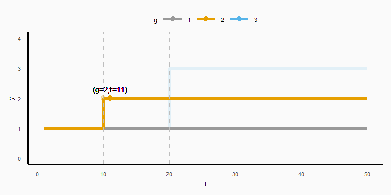

## The CD decomposition

*Chaisemartin & D’Haultfoeuille (CD): “Two-way fixed effects estimators with heterogeneous treatment effects” (forthcoming, AER)*

**Decompose $\beta_{fe}$ in weighted TEs across $(g,t):D_{g,t}=1$ cells**

- i.e. for the cell $g=2,t=12$, weight number: 3

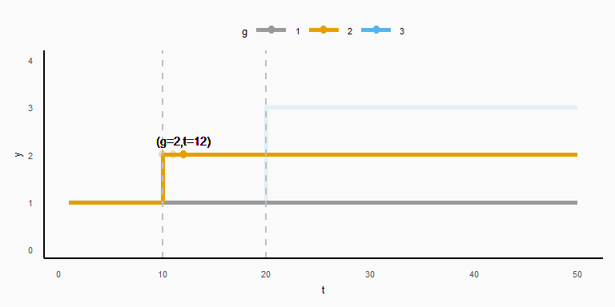

## The CD decomposition

*Chaisemartin & D’Haultfoeuille (CD): “Two-way fixed effects estimators with heterogeneous treatment effects” (forthcoming, AER)*

**Decompose $\beta_{fe}$ in weighted TEs across $(g,t):D_{g,t}=1$ cells**

- i.e. for the cell $g=2,t=13$, weight number: 4

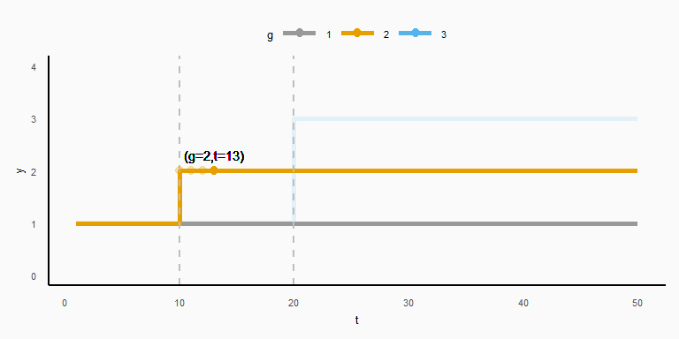

## The CD decomposition

*Chaisemartin & D’Haultfoeuille (CD): “Two-way fixed effects estimators with heterogeneous treatment effects” (forthcoming, AER)*

**Decompose $\beta_{fe}$ in weighted TEs across $(g,t):D_{g,t}=1$ cells**

- i.e. for the cell $g=3,t=50$, weight number: 72

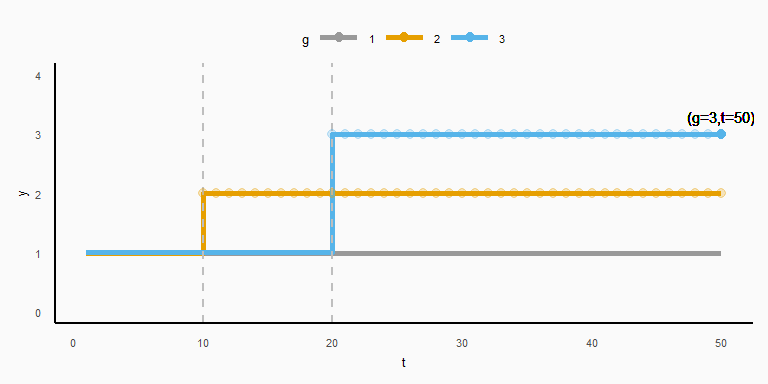

## The CD decomposition

**Decompose $\beta_{fe}$ in weighted TEs across $(g,t):D_{g,t}=1$ cells**

- $\beta_{fe}$ is then given by

$$\begin{align}
\beta_{fe}=E\left[\sum_{(g,t):D_{g,t}=1} \frac{N_{g,t}}{N_{D=1}}
w_{g,t}\Lambda_{g,t}\right]
\end{align}$$

where

- $w_{g,t}$ is the weight on group $g$ in period $t$
- $\Lambda_{g,t}$ is the TE in group $g$ in period $t$
- $N_{D=1}$ is the number of treated units.
- $N_{g,t}$ is the number of observations in cell $g$ and $t$.

**See Theorem 1 in CD**

- How are the weights defined?

## CD: Calculating the weights

**Calculating the CD weights**

1. Run a regression of $D_{g,t}$ on a constant, $g$ and $t$ fixed effects.
2. Save the residual, $e_{fe,g,t}$
3. Create the weight of that cell as

$$\begin{align}
w_{fe,g_t}=\frac{e_{fe,g,t}}{\sum_{(g,t):D_{g,t}=1}
\frac{N_{g,t}}{N_{D=1}}e_{fe,g,t}}
\end{align}$$

**Intuition**

- Consider cell $(g,t)$ from a group that is treated for almost the entire period and at a time where almost all cells are treated.
- We would predict that this cell is treated (because it is from a group that is mostly treated at a time that is mostly treated).
- $\Rightarrow$ small or even negative residual
- $\Rightarrow$ small or even negative weight.

## An example from CD

- 2 equally sized groups, 3 periods
  - group 1 is only treated in period 3
  - group 2 is treated in period 2 and 3
- The weights are then:
  - $e_{fe,1,3}=1/6$
  - $e_{fe,2,2}=2/6$
  - $e_{fe,2,3}=-1/6$
- So that $\beta_{fe}=1/2 \times E(\Lambda_{1,3}) + 1\times E(\Lambda_{2,2}) - 1/2 \times E(\Lambda_{2,3})$
- If for example $E(\Lambda_{2,3})=4$ & $E(\Lambda_{1,3})=E(\Lambda_{2,2})=1$, then $\beta_{fe}=-1/2$
- Estimate is negative, although all cell’s treatment effects are positive!
- This is only an issue with heterogenous treatment effects.

## Let’s calculate the weights in our example

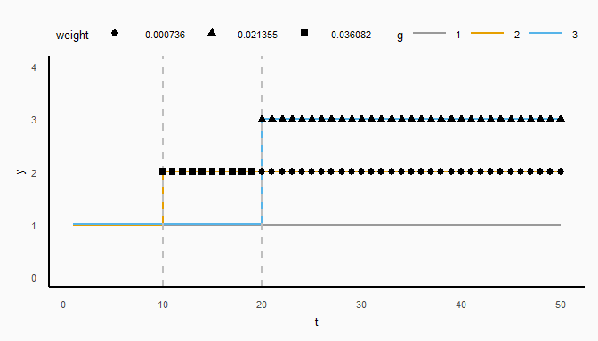

- Largest weight at the beginning: few groups are treated. - Group 2 cells even get negative weight after $t=20$ because they are from a group that is mostly treated and at a time that that is mostly treated.

**And using equation (5) we get**:

- $\hat{\beta}_{fe}$=10 $\times$ 0.03608 $\times$ 1+ 31 $\times$ 0.02135 $\times$ 2- 31 $\times$ 0.0007361 $\times$ 1=1.66
- Note: the cells’ TEs are normally unobserved (we know the DGP).

## Can we link the CD and GB weights?

**The GB weights**

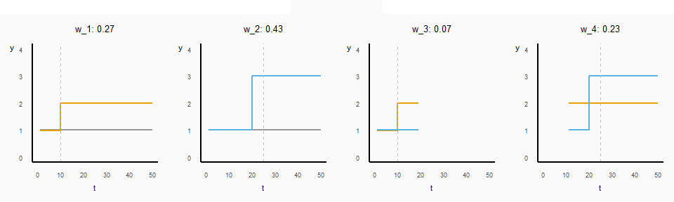

- Sum of weights where G=2 is treated: 0.27+0.07=0.34
- Sum of weights where G=3 is treated: 0.43+0.23= 0.66

**The CD weights**

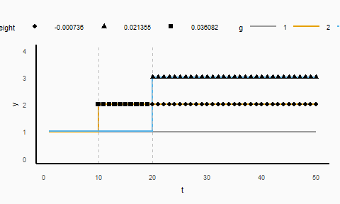

- Sum of weights where G=2 is treated: 10 $\times$ 0.03608 -31 $\times$ 0.0007361=0.34
- Sum of weights where G=3 is treated: 31 $\times$ 0.02135=0.66.

## Back to CD

**So what should we do?**

1. Calculate weights of the cells!
2. If you have negative weights: calculate $\underline{\sigma}_{fe}$ (See Corollary 1 in the paper)
- tells us the amount of treatment heterogeneity that is required to for the pop weighted average treatment effect to have the opposite sign of $\hat{\beta}_{fe}$.
- So if $\underline{\sigma}_{fe}$ is very small you should be worried!
- Are treatment effects likely to be correlated with weights? Check if weights are correlated with covariates.
3. If things still look bad: use their new estimator: $DID_M$
- Identies average effect across switching cells:
  $$\begin{align}
  DID_M=\sigma^T_{t=2}\left(\overbrace{\frac{N_{1,0,t}}{N_S}DID_{+,t}}^{\text{"joiners"}}+\overbrace{\frac{N_{0,1,t}}{N_S}DID_{-,t}}^{\text{"leavers"}}
  \right)
  \end{align}$$
4. In Stata
- calculates weights and $\underline{\sigma}_{fe}$
- estimates $DID_M$
- R is on the way

## Read!

Read both papers. There are many more insights in the papers.

- Check assumptions!
- Adding controls
- First differences
- Placebo tests
- Correlation between weights and covariates

… and much more

## Summary

Question: What is $\hat{\beta}_{fe}$ from OLS regression of:
$$y_{i,g,t}=\alpha+\gamma'
G_{g}+\psi' T_{t}+ \beta_{fe} D_{g,t}+e_{i,g,t}$$
capturing?

- Goodman-Bacon (2019, WP) shows that in a staggered adoptation design we can think of this as a weighted average of all possible difference-in-differences.
  - Weights are not equal to population weights, but depend on when units become treated!
  - Has implications for common trend assumption.
  - DDs might enter with opposite sign if treatment effect varies over time.
- Chaisemartin & D’Haultfoeuille (forthcoming, AER) show that $\hat{\beta}_{fe}$ is a weighted average across all treated $(g,t)$ cells.
  - The weights can be negative and bias estimates when TEs are heterogeneous!
  - Provides a quantification of the degree of TE heterogeneity required in order to flip the sign.
  - Provides a new estimator.
  - And much more.

## What I will do now

1. Calculate Chaisemartin & D’Haultfoeuille weights (with in Stata or manually in R).
2. If I have negative weights, I’ll check how much treatment heterogeneity is required to flip the sign (with in Stata).
3. If 2. is small and it is meaningful, I’ll apply their new estimator.
- Note it only identifies from switching cells!
4. If I have a staggered adoption design: check for negative DDs using GB approach (using in Stata).
5. Create event study charts if possible.
6. Use new toolbox to check placebo effects/ weighted common trend assumptions.

## Thanks

Thanks to Clément, Xavier & Andrew for excellent papers!